# Make Words, Not War! The impact of information dissemination on conflicts

Final Project Econometrics

Author

Louise Guez, Joachim Schwartz

# Introduction

This project is based on a paper from Armand et al. (2020). Armand et al. (2020) investigate through a RCT how different types of information dissemination about the discovery of a new natural resource in Mozambique modify political behaviour and lead to violent events or not. Our project aims at verifying the consistency of their econometric model thanks to simulation tools.

```r
rm(list = ls())

### WD Louise ###

# setwd("")

### WD Joachim ###

setwd("C:/Users/schwa/Dropbox/Final_project_metrics/Replication")

### Packages used ###

library(tidyverse)
library(stargazer)
library(haven)
library(fixest)
library(knitr)
library(kableExtra)
library(modelsummary)
library(broom)
library(MASS)
```

## Load the data

We download the data and the main do-file (in STATA) from the replication packages of Armand et al. (2020).

```r
data <- read_dta("MozNatRes_Mozambique.dta")
```

First, we replicate part of their results. Then, we do fake and real data simulations to assess the relevance of their model, and we add an extension through the introduction of a categorical variable taking into account the distance of the violent events to the community.

# Replication

In Armand et al. (2020), two treatments were implemented :

- In the first group of randomly-selected communities, only local political leaders received the information module (*leader* *treatment*).
- In the second group, the information module was delivered to both local leaders and citizens, targeting communities at large while aiming to provide higher levels of accountability (*community treatment*).

In the control group, there was no dissemination’s effects organized.

To conduct their analyzes, the author considered different outcomes variables, but we only focus on what matters the most, i.e. the presence of violent events.

The model they use and that we replicate is the following one:

$$Y_{ijt} = \beta_0 + \beta_1 T_{1j} + \beta_2 T_{2j} + \gamma Y_{ijt-1} + \delta \mathbf{X}_{ij} + \varepsilon_{ij}$$

With the following variables:

- $Y_{ijt}$ is the a dummy variable that takes $1$ if violent event occur in year $t$ within 5km to the community $j$ where individual $i$ lives.
- $Y_{ijt-1}$ is a lag variable that takes $1$ if violent event occur in year $t-1$ within 5km to the community $j$ where individual $i$ lives.
- $T_{1j}$ is a dummy variable that takes $1$ if community $j$ received the *leader treatment.*
- $T_{2j}$ is a dummy variable that takes $1$ if community $j$ received the *community treatment.*
- $\mathbf{X}_{ij}$ is a vector of leader and community controls.

The following code is our replication for the three first columns in TABLE 1 of Armand et al. (2020). We have three regressions depending on the outcome (ACLED, GDELT, ACLED + GDELT)

```r
### Control variables

contr_ld <- c("ld_age", "ld_educ_2", "ld_educ_3", "ld_rel_muslim", "ld_ethn_macua", "ld_ethn_maconde", "ld_adults_HH", "ld_a16", "ld_married", "strata_rnd1", "strata_rnd2", "strata_rnd3", "num_tables_14", "distpalma")

data$tr_2 <- data$tr_2 + data$tr_3

###### REG 1

### Creation of a "lag" (Claude AI)
data_reg <- data %>%
  arrange(hh_id, year) %>%
  group_by(hh_id) %>%
  mutate(dev_a_5km_lag = lag(dev_a_5km)) %>%
  ungroup() %>%
  # Filter for the 206 obs
  filter(year == 2017, villobs == 1)

### Regression
formula_str <- paste("dev_a_5km ~ tr_1 + tr_2 + dev_a_5km_lag +",
                     paste(contr_ld, collapse = " + "))
reg1 <- feols(as.formula(formula_str),
             data = data_reg,
             cluster = "hh_id")

# Results
# summary(reg1)


####### REG 2

data_reg2 <- data %>%
  arrange(hh_id, year) %>%
  group_by(hh_id) %>%
  mutate(dev_b_5km_lag = lag(dev_b_5km)) %>%
  ungroup() %>%
  filter(year == 2017, villobs == 1)

formula_str2 <- paste("dev_b_5km ~ tr_1 + tr_2 + dev_b_5km_lag +",
                      paste(contr_ld, collapse = " + "))
reg2 <- feols(as.formula(formula_str2),
              data = data_reg2,
              cluster = "hh_id")

#summary(reg2)


##### REG 3

data_reg3 <- data %>%
  arrange(hh_id, year) %>%
  group_by(hh_id) %>%
  mutate(dev_c_5km_lag = lag(dev_c_5km)) %>%
  ungroup() %>%
  filter(year == 2017, villobs == 1)

formula_str3 <- paste("dev_c_5km ~ tr_1 + tr_2 + dev_c_5km_lag +",
                     paste(contr_ld, collapse = " + "))
reg3 <- feols(as.formula(formula_str3),
              data = data_reg3,
              cluster = "hh_id")

#summary(reg3)

#### Table

models <- list(
  "ACLED" = reg1,
  "GDELT" = reg2,
  "ACLED + GDELT" = reg3
)

reg_table <- modelsummary(models,
                          title = "Impact of Information Campaign on Violence (5km radius)",
                          stars = c('*' = 0.1, '**' = 0.05, '***' = 0.01),
                          gof_map = c("nobs", "r.squared"),
                          coef_map = c(
                            "tr_1" = "Treatment 1",
                            "tr_2" = "Treatment 2"
                          ),
                          output = "kableExtra",
                          notes = list(
                            "Standard errors clustered at household level",
                            "All regressions include baseline controls"
                          )
)

reg_table
```

Impact of Information Campaign on Violence (5km radius)

|  | ACLED | GDELT | ACLED + GDELT |
| --- | --- | --- | --- |
| Treatment 1 | −0.034 | −0.019 | −0.050 |
|  | (0.033) | (0.029) | (0.037) |
| Treatment 2 | −0.050 | −0.039 | −0.063* |
|  | (0.032) | (0.025) | (0.033) |
| Num.Obs. | 206 | 206 | 206 |
| R2 | 0.200 | 0.696 | 0.610 |

* p < 0.1, ** p < 0.05, *** p < 0.01  
Standard errors clustered at household level  
All regressions include baseline controls

As in Armand et al. (2020), we find that the *community treatment* is significant in reducing the presence of violent event within 5km to the community. Our coefficients are not exactly the same than in Armand et al. due to some controls we did not input in our model for sake of simplicity (infrastructure, natural resources, ethnicity).

Next, our goal is to run various simulations in order to retrieve the same rough estimates for our effects of interest.

# Fake data simulation

First, we generate a fake data simulation and try to retrieve the effect of interest for the main outcome (violent event according to ACLED + GDELT).

## Data exploration and calibration

To understand better how observations are distributed across treatments or outcomes in the RCT of Armand et al. (2020), we do some calculations based on the real data.

```r
data_RCT <- data

# Obs. by year
sum(data_RCT$year == 2016)
```

```
[1] 2065
```

```r
sum(data_RCT$year == 2017)
```

```
[1] 2103
```

```r
#Obs. by year and treatment
sum(data_RCT$tr_1 == 1 & data_RCT$year == 2016)
```

```
[1] 500
```

```r
sum(data_RCT$tr_2 == 1 & data_RCT$year == 2016)
```

```
[1] 1014
```

```r
sum(data_RCT$tr_3 == 1 & data_RCT$year == 2016)
```

```
[1] 500
```

```r
#Obs. by year and outcome
sum(data_RCT$dev_c_5km == 1 & data_RCT$year == 2016)
```

```
[1] 60
```

```r
sum(data_RCT$dev_c_5km == 1 & data_RCT$year == 2017)
```

```
[1] 172
```

N.B. : “dev_c_5km” refers to the main outcome: presence of violent event within 5km to the community according to the ACLED + GDELT databases.

Note that there is “tr_3” for a third treatment, which is a variant of the *community treatment* (“tr_2”). Armand et al. (2020) combine this two treatments into the *community treatment* (“tr_2”), and we do the same.

## Simple data generating process

Our simple DGP is designed in order to estimate the following model :

$$Y_{ijt} = \beta_0 + \beta_1 T_{1j} + \beta_2 T_{2j} + \gamma Y_{ijt-1} + \varepsilon_{ij}$$

First, we generate the data.

```
# A tibble: 1,000 × 6
         u dev_c_5km_2016 tr_1  tr_2  dev_c_5km_2017 dummy_dev_c_5km_2017
     <dbl> <lgl>          <lgl> <lgl>          <dbl>                <dbl>
 1 -0.0245 FALSE          FALSE TRUE         -0.160                     0
 2  0.252  FALSE          FALSE TRUE          0.117                     1
 3 -0.0598 FALSE          TRUE  TRUE         -0.245                     0
 4 -0.374  FALSE          FALSE TRUE         -0.509                     0
 5  0.285  FALSE          FALSE FALSE         0.235                     1
 6  0.131  FALSE          TRUE  TRUE         -0.0541                    0
 7  0.263  FALSE          FALSE TRUE          0.128                     1
 8  0.0214 FALSE          FALSE FALSE        -0.0286                    0
 9  0.155  FALSE          FALSE TRUE          0.0198                    0
10 -0.244  FALSE          FALSE TRUE         -0.379                     0
# ℹ 990 more rows
```

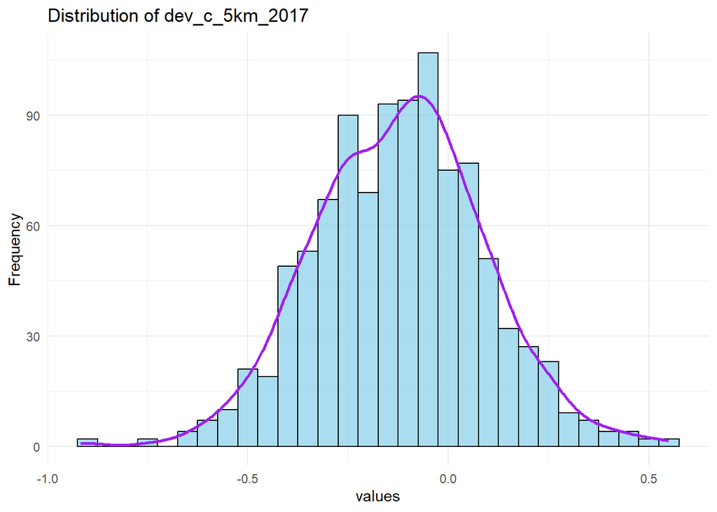

```r
# Function to generate fake data
generate_data <- function(n,
                          beta_0,
                          beta_1,
                          beta_2,
                          gamma,
                          sigma_u,
                          p_dev,
                          p_treat_t1,
                          p_treat_t2) {
  tibble(
    u = rnorm(n, 0, sigma_u),
    dev_c_5km_2016 = rbernoulli(n, p = p_dev),
    tr_1 = rbernoulli(n, p = p_treat_t1),
    tr_2 = rbernoulli(n, p = p_treat_t2),
    dev_c_5km_2017 = beta_0 + beta_1 * as.numeric(tr_1) + beta_2 * as.numeric(tr_2) + gamma * dev_c_5km_2016 + u,
    dummy_dev_c_5km_2017 = ifelse(dev_c_5km_2017 >= 0.1, 1, 0)
  )
}

# Baseline parameters

baseline_param <-
  tibble(
    n = 1000,
    beta_0 = -0.05,
    beta_1 = -0.05,
    beta_2 = -0.085,
    gamma = -0.4,
    sigma_u = 0.2,
    p_dev = 0.03,
    p_treat_t1 = 0.25,
    p_treat_t2 = 0.5,
  )

baseline_param |>
  purrr::pmap(.f = generate_data) |>
  list_rbind() |>
  print(n = 10) |>
  # Vérifier la distribution de la variable "dev_c_5km_2017"
  (\(data) {
    ggplot(data, aes(x = dev_c_5km_2017)) +
      geom_histogram(binwidth = 0.05, fill = "skyblue", color = "black", alpha = 0.7) +
      geom_density(aes(y = 0.05 * ..count..), color = "purple", size = 1) +
      labs(title = "Distribution of dev_c_5km_2017", x = "values", y = "Frequency") +
      theme_minimal()
  })()
```

## Estimation(s)

Then, we estimate the baseline model, similar to the replication but without the controls :

$$Y_{ijt} = \beta_0 + \beta_1 T_{1j} + \beta_2 T_{2j} + \gamma Y_{ijt-1} + \varepsilon_{ij}$$

```r
## Estimation

run_estim <- function(data) {
  feols(dummy_dev_c_5km_2017 ~ tr_1 + tr_2 + dev_c_5km_2016, data = data) |>
    summary() |>
    broom::tidy(conf.int = TRUE, conf.level = 0.95) |>
    filter(term %in% c("tr_1TRUE", "tr_2TRUE")) |>
    dplyr::select(-term)
}

baseline_param |>
  purrr::pmap(.f = generate_data) |>
  list_rbind() |> #pmap returns a list, turn it into a data frame
  run_estim() |>
  kable()
```

| estimate | std.error | statistic | p.value | conf.low | conf.high |
| --- | --- | --- | --- | --- | --- |
| -0.0371685 | 0.0283044 | -1.313170 | 0.1894282 | -0.0927117 | 0.0183746 |
| -0.0821372 | 0.0237700 | -3.455495 | 0.0005725 | -0.1287823 | -0.0354921 |

Now, we repeat the simulation 100 times.

```r
compute_sim <- function(...) {
  generate_data(...) %>%
    run_estim()
}

baseline_param |>
  purrr::pmap(.f = compute_sim) |>
  list_rbind() |>
  kable()
```

| estimate | std.error | statistic | p.value | conf.low | conf.high |
| --- | --- | --- | --- | --- | --- |
| -0.0394881 | 0.0274783 | -1.437067 | 0.1510130 | -0.0934101 | 0.0144338 |
| -0.0880461 | 0.0232674 | -3.784103 | 0.0001635 | -0.1337048 | -0.0423874 |

```r
n_iter <- 100

param <- baseline_param |>
  uncount(n_iter)

param |>
  slice(1:10) |>
  kable()
```

| n | beta_0 | beta_1 | beta_2 | gamma | sigma_u | p_dev | p_treat_t1 | p_treat_t2 |
| --- | --- | --- | --- | --- | --- | --- | --- | --- |
| 1000 | -0.05 | -0.05 | -0.085 | -0.4 | 0.2 | 0.03 | 0.25 | 0.5 |
| 1000 | -0.05 | -0.05 | -0.085 | -0.4 | 0.2 | 0.03 | 0.25 | 0.5 |
| 1000 | -0.05 | -0.05 | -0.085 | -0.4 | 0.2 | 0.03 | 0.25 | 0.5 |
| 1000 | -0.05 | -0.05 | -0.085 | -0.4 | 0.2 | 0.03 | 0.25 | 0.5 |
| 1000 | -0.05 | -0.05 | -0.085 | -0.4 | 0.2 | 0.03 | 0.25 | 0.5 |
| 1000 | -0.05 | -0.05 | -0.085 | -0.4 | 0.2 | 0.03 | 0.25 | 0.5 |
| 1000 | -0.05 | -0.05 | -0.085 | -0.4 | 0.2 | 0.03 | 0.25 | 0.5 |
| 1000 | -0.05 | -0.05 | -0.085 | -0.4 | 0.2 | 0.03 | 0.25 | 0.5 |
| 1000 | -0.05 | -0.05 | -0.085 | -0.4 | 0.2 | 0.03 | 0.25 | 0.5 |
| 1000 | -0.05 | -0.05 | -0.085 | -0.4 | 0.2 | 0.03 | 0.25 | 0.5 |

```r
result_sim <- pmap(param, compute_sim) |>
  list_rbind()

repeat_times <- ceiling(nrow(result_sim) / nrow(param))

param_expanded <- param[rep(1:nrow(param), times = repeat_times), ]

param_expanded <- param_expanded[1:nrow(result_sim), ]

result_sim <- bind_cols(result_sim, param_expanded)

head(result_sim)
```

```
# A tibble: 6 × 15
  estimate std.error statistic    p.value conf.low conf.high     n beta_0 beta_1
     <dbl>     <dbl>     <dbl>      <dbl>    <dbl>     <dbl> <dbl>  <dbl>  <dbl>
1  -0.0381    0.0273    -1.40     1.63e-1  -0.0917    0.0155  1000  -0.05  -0.05
2  -0.0847    0.0238    -3.56     3.94e-4  -0.131    -0.0380  1000  -0.05  -0.05
3  -0.0350    0.0252    -1.39     1.64e-1  -0.0844    0.0143  1000  -0.05  -0.05
4  -0.133     0.0221    -6.02     2.45e-9  -0.176    -0.0896  1000  -0.05  -0.05
5  -0.0199    0.0265    -0.750    4.53e-1  -0.0720    0.0322  1000  -0.05  -0.05
6  -0.0923    0.0234    -3.94     8.65e-5  -0.138    -0.0463  1000  -0.05  -0.05
# ℹ 6 more variables: beta_2 <dbl>, gamma <dbl>, sigma_u <dbl>, p_dev <dbl>,
#   p_treat_t1 <dbl>, p_treat_t2 <dbl>
```

```r
## N.B.: Help from GPT to overcome issues in the number of rows.
```

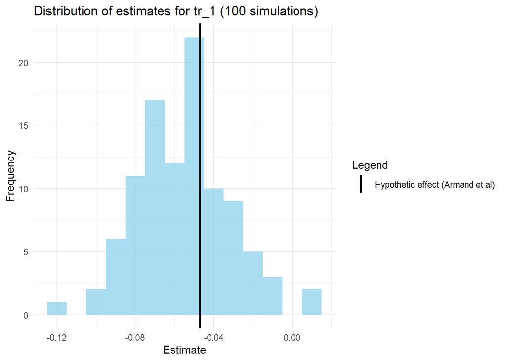

```r
#### Graph.


result_sim$treatment <- ifelse(seq_len(nrow(result_sim)) %% 2 == 1, "tr_1", "tr_2")

tr_1_data <- result_sim[result_sim$treatment == "tr_1", ]
tr_2_data <- result_sim[result_sim$treatment == "tr_2", ]

# Tracer la distribution pour tr_1
lines_data_1 <- data.frame(
  x = -0.047,
  label = "Hypothetic effect (Armand et al)"
)

plot_tr1 <- ggplot(tr_1_data, aes(x = estimate)) +
  geom_histogram(binwidth = 0.01, fill = "skyblue", alpha = 0.7) +
  geom_vline(data = lines_data_1, aes(xintercept = x, color = label), linetype = "solid", size = 1) +
  scale_color_manual(
    values = c("Hypothetic effect (Armand et al)" = "black"),
    name = "Legend"
  ) +
  labs(title = "Distribution of estimates for tr_1 (100 simulations)",
       x = "Estimate",
       y = "Frequency") +
  theme_minimal()


print(plot_tr1)
```

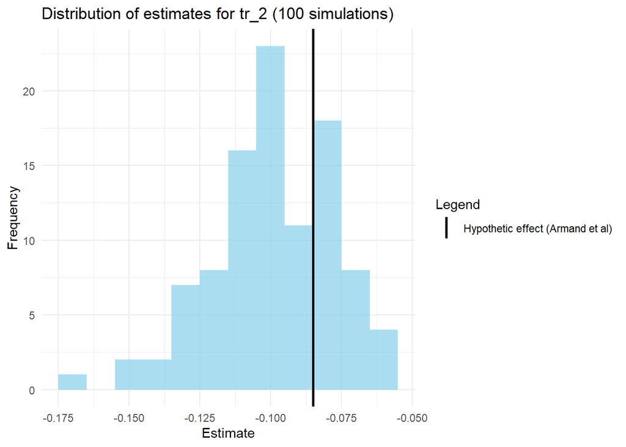

```r
# Tracer la distribution pour tr_2
lines_data_2 <- data.frame(
  x = -0.085,
  label = "Hypothetic effect (Armand et al)"
)

plot_tr2 <- ggplot(tr_2_data, aes(x = estimate)) +
  geom_histogram(binwidth = 0.01, fill = "skyblue", alpha = 0.7) +
  geom_vline(data = lines_data_2, aes(xintercept = x, color = label), linetype = "solid", size = 1) +
  scale_color_manual(
    values = c("Hypothetic effect (Armand et al)" = "black"),
    name = "Legend"
  ) +
  labs(title = "Distribution of estimates for tr_2 (100 simulations)",
       x = "Estimate",
       y = "Frequency") +
  theme_minimal()


print(plot_tr2)
```

We partially retrieve the effect of Armand et al (2020) for the *leader treatment*. But most of the estimates are far away from the hypothetic effect of $\beta_2$ (*community treatment*). It could highlight some weaknesses of the model, but it could also come from a potential dichotomy between the DGP and the estimated model, due to the way we generated the dummy outcome (cf. supra).

We determine the statistical power depending on various sample sizes :

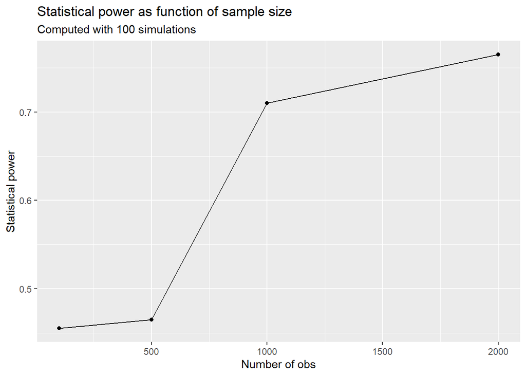

```r
vect_n <- c(100, 500, 1000, 2000)

param <- baseline_param |>
  dplyr::select(-n) |>
  crossing(n = vect_n) |>
  uncount(n_iter)

sim_res <- param |>
  pmap(compute_sim) |>
  list_rbind()

repeat_times <- ceiling(nrow(sim_res) / nrow(param))

param_expanded2 <- param[rep(1:nrow(param), times = repeat_times), ]

param_expanded2 <- param_expanded2[1:nrow(sim_res), ]

sim_res <- bind_cols(sim_res, param_expanded2)


power_res <- sim_res |>
  mutate(signif = (p.value < 0.05)) |>
  group_by(n) |>
  summarize(
    power = mean(signif)
  )

# Plot the graph

power_res |>
  ggplot(aes(x = n, y = power)) +
  geom_point() +
  geom_line() +
  labs(
    title = "Statistical power as function of sample size",
    subtitle = paste("Computed with", n_iter, "simulations"),
    x = "Number of obs",
    y = "Statistical power"
  )
```

This graph shows poor results in terms of statistical power. It means that we hardly detect an existing effect, especially when the sample size is low. However, we may think that a huge sample size could make the model powerful enough.

# Real data simulation

The goal of this part is to check the robustness of the model and to investigate for some potential pitfalls which could explain the difficulties we have to retrieve the effects of interest.

## Normal distribution of errors

Based on our replication, which is our best way to approximate the model of Armand et al. (2020), we investigate the normal distribution of errors. This could be determinant in so far as they use a simple OLS model, but with a binary outcome.

We use the Shapiro-Wilk test, which is often used for small samples.

```r
residuals_reg3 <- resid(reg3)

shapiro_test_reg3 <- shapiro.test(residuals_reg3)
print(shapiro_test_reg3)
```

```
    Shapiro-Wilk normality test

data:  residuals_reg3
W = 0.79299, p-value = 8.364e-16
```

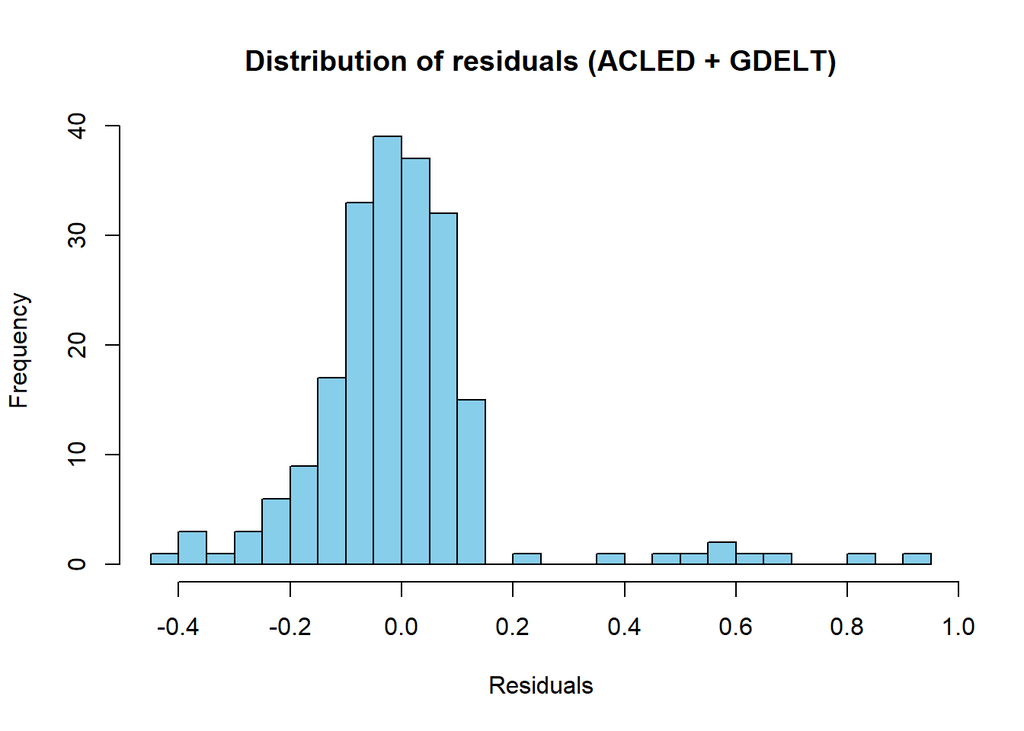

```r
hist(residuals_reg3, breaks = 30, main = "Distribution of residuals (ACLED + GDELT)", col = "skyblue", xlab = "Residuals")
```

## Bootstrap

Here, we simulate the model used for the replication (simple model + alsmost all the controls) on several samples randomly generated from the real data of Armand et al. (2020). It allows us to compare the estimates we find in the replication and the ones found by Armand et al. (2020) with the ones provided by various simulations on real data.

```r
n_boot <- 1000

bootstrap_feols <- function(data, formula, cluster, n_boot = 1000) {

  coef_names <- names(coef(feols(as.formula(formula), data = data, cluster = cluster)))
  boot_results <- matrix(NA, nrow = n_boot, ncol = length(coef_names))
  colnames(boot_results) <- coef_names

  for (i in 1:n_boot) {

    boot_sample <- data[sample(1:nrow(data), size = nrow(data), replace = TRUE), ]

    tryCatch({
      model <- feols(as.formula(formula), data = boot_sample, cluster = cluster)
      boot_results[i, ] <- coef(model)  # Stocker les coefficients
    }, error = function(e) {
      message(paste("Erreur à l'itération", i, ":", e$message))
    })
  }

  boot_results <- as.data.frame(boot_results)
  return(boot_results)
}

### Apply the bootstrap on reg_3 ####
formula_str <- paste("dev_c_5km ~ tr_1 + tr_2 + dev_c_5km_lag +", paste(contr_ld, collapse = " + "))
bootstrap_results <- bootstrap_feols(data_reg3, formula_str, cluster = "hh_id", n_boot = 1000)

summary(bootstrap_results)
```

```
  (Intercept)           tr_1              tr_2         dev_c_5km_lag
 Min.   :-0.2871   Min.   :-0.1808   Min.   :-0.1843   Min.   :-0.7637
 1st Qu.:-0.1066   1st Qu.:-0.0747   1st Qu.:-0.0826   1st Qu.:-0.4935
 Median :-0.0425   Median :-0.0473   Median :-0.0606   Median :-0.4127
 Mean   :-0.0444   Mean   :-0.0492   Mean   :-0.0614   Mean   :-0.4127
 3rd Qu.: 0.0169   3rd Qu.:-0.0255   3rd Qu.:-0.0377   3rd Qu.:-0.3286
 Max.   : 0.3095   Max.   : 0.0609   Max.   : 0.0256   Max.   :-0.0518
 NA's   :356       NA's   :356       NA's   :356       NA's   :356
     ld_age          ld_educ_2         ld_educ_3       ld_rel_muslim
 Min.   :-0.0025   Min.   :-0.1256   Min.   :-0.1430   Min.   :-0.0701
 1st Qu.: 0.0014   1st Qu.:-0.0522   1st Qu.:-0.0201   1st Qu.:-0.0192
 Median : 0.0023   Median :-0.0338   Median : 0.0087   Median :-0.0054
 Mean   : 0.0024   Mean   :-0.0333   Mean   : 0.0103   Mean   :-0.0043
 3rd Qu.: 0.0034   3rd Qu.:-0.0147   3rd Qu.: 0.0386   3rd Qu.: 0.0111
 Max.   : 0.0077   Max.   : 0.0894   Max.   : 0.1764   Max.   : 0.0831
 NA's   :356       NA's   :356       NA's   :356       NA's   :356
 ld_ethn_macua     ld_ethn_maconde    ld_adults_HH         ld_a16
 Min.   :-0.4781   Min.   :-0.5274   Min.   :-0.0179   Min.   :-0.1726
 1st Qu.:-0.1706   1st Qu.:-0.1916   1st Qu.: 0.0041   1st Qu.:-0.0819
 Median :-0.1216   Median :-0.1448   Median : 0.0138   Median :-0.0588
 Mean   :-0.1243   Mean   :-0.1443   Mean   : 0.0139   Mean   :-0.0578
 3rd Qu.:-0.0732   3rd Qu.:-0.0918   3rd Qu.: 0.0228   3rd Qu.:-0.0310
 Max.   : 0.0481   Max.   : 0.0535   Max.   : 0.0470   Max.   : 0.0595
 NA's   :356       NA's   :356       NA's   :356       NA's   :356
   ld_married       strata_rnd1       strata_rnd2      strata_rnd3
 Min.   :-0.0570   Min.   :-0.1111   Min.   :0.7773   Min.   :-0.1071
 1st Qu.: 0.0020   1st Qu.: 0.2094   1st Qu.:1.0085   1st Qu.: 0.0102
 Median : 0.0200   Median : 0.2972   Median :1.0669   Median : 0.0595
 Mean   : 0.0190   Mean   : 0.3045   Mean   :1.0666   Mean   : 0.0641
 3rd Qu.: 0.0346   3rd Qu.: 0.3873   3rd Qu.:1.1254   3rd Qu.: 0.1102
 Max.   : 0.1038   Max.   : 0.9110   Max.   :1.3906   Max.   : 0.3437
 NA's   :356       NA's   :356       NA's   :356      NA's   :356
 num_tables_14       distpalma
 Min.   :-0.0006   Min.   :-0.0374
 1st Qu.: 0.0314   1st Qu.: 0.0417
 Median : 0.0407   Median : 0.0588
 Mean   : 0.0407   Mean   : 0.0597
 3rd Qu.: 0.0502   3rd Qu.: 0.0766
 Max.   : 0.0798   Max.   : 0.1527
 NA's   :356       NA's   :356
```

```r
 ###Calculation of confidence intervals ###
ci <- apply(bootstrap_results, 2, function(x) quantile(x, probs = c(0.025, 0.975), na.rm = TRUE))
print(ci)
```

```
      (Intercept)       tr_1          tr_2 dev_c_5km_lag        ld_age
2.5%   -0.2175974 -0.1190712 -0.1309524077    -0.6098554 -0.0004397877
97.5%   0.1579642  0.0213173 -0.0006644803    -0.2049492  0.0053368642
        ld_educ_2   ld_educ_3 ld_rel_muslim ld_ethn_macua ld_ethn_maconde
2.5%  -0.08317733 -0.06891304   -0.04925219  -0.265578688    -0.297123019
97.5%  0.02080254  0.09719692    0.03784872   0.004757679     0.001873201
      ld_adults_HH      ld_a16  ld_married strata_rnd1 strata_rnd2 strata_rnd3
2.5%  -0.009643727 -0.13708822 -0.02464617  0.05410055   0.9008777 -0.06807225
97.5%  0.037787980  0.01428208  0.06541128  0.61492408   1.2441003  0.22288730
      num_tables_14   distpalma
2.5%     0.01347265 0.005683289
97.5%    0.06722953 0.114770378
```

```r
filtered_results <- bootstrap_results %>%
  dplyr::select(tr_1, tr_2)
summary(filtered_results)
```

```
      tr_1              tr_2
 Min.   :-0.1808   Min.   :-0.1843
 1st Qu.:-0.0747   1st Qu.:-0.0826
 Median :-0.0473   Median :-0.0606
 Mean   :-0.0492   Mean   :-0.0614
 3rd Qu.:-0.0255   3rd Qu.:-0.0377
 Max.   : 0.0609   Max.   : 0.0256
 NA's   :356       NA's   :356
```

```r
### Calcul des intervalles de confiance pour `tr_1` et `tr_2`
ci <- apply(filtered_results, 2, function(x) quantile(x, probs = c(0.025, 0.975), na.rm = TRUE))
print(ci)
```

```
            tr_1          tr_2
2.5%  -0.1190712 -0.1309524077
97.5%  0.0213173 -0.0006644803
```

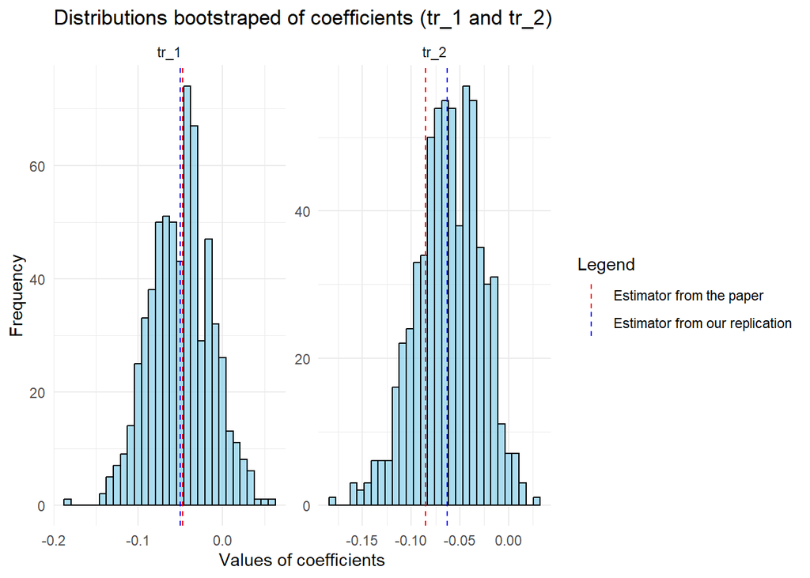

```r
filtered_results %>%
  pivot_longer(cols = everything(), names_to = "Coefficient", values_to = "Value") %>%
  ggplot(aes(x = Value)) +
  geom_histogram(bins = 30, fill = "skyblue", color = "black", alpha = 0.7) +
  geom_vline(data = tibble(Coefficient = c("tr_1", "tr_2"), Value = c(-0.047, -0.085), Type = "Paper Estimator"),
             aes(xintercept = Value, color = Type), linetype = "dashed") +
  geom_vline(data = tibble(Coefficient = c("tr_1", "tr_2"), Value = c(-0.050, -0.063), Type = "Replication Estimator"),
             aes(xintercept = Value, color = Type), linetype = "dashed") +
  scale_color_manual(
    name = "Legend",
    values = c("Paper Estimator" = "red", "Replication Estimator" = "blue"),
    labels = c("Estimator from the paper", "Estimator from our replication")
  ) +
  facet_wrap(~ Coefficient, scales = "free") +
  labs(
    title = "Distributions bootstraped of coefficients (tr_1 and tr_2)",
    x = "Values of coefficients",
    y = "Frequency"
  ) +
  theme_minimal()
```

We observe the empirical distribution of the coefficients by simulating multiple samples for the variables tr_1 and tr_2 on the outcome dev_c_5km. These distributions appear to be mostly centered around both the theoretical and empirical effects. The estimate for Treatment 1 (tr_1) is relatively well aligned with the replication results, closely approximating the original effect. However, this alignment is weaker for the estimate of Treatment 2 (tr_2), where the replicated estimate deviates more noticeably from the theoretical effect. Overall, we find that our replication captures the effect of Treatment 1 more accurately than that of Treatment 2, indicating greater difficulty in replicating the original effect of Treatment 2.

## Extension with categorical variable

In order to add a categorical variable in our analysis, we modify the main outcome to take into account the distance of violent events to the community. The outcome “presence of violent events according to ACLED and GDLET” takes now four possible values:

- “close” when a violent event occurred within 3km to the community
- “med” when a violent event occurred between 3 and 5km away from the community
- “away” when a violent event occurred between 5 and 7km away from the community
- “none” when no violent event was recorded within 7km.

We are looking for if being treated decrease the probability to have a violent event close to community.

To handle this new categorical outcome, we use **an ordered logit model**. The goal is to see if we retrieve quite the same estimates for our effects of interest than with the model proposed by Armand et al. (2020) and which we replicated.

First, we create the new variable from the real data and we derive its “lag”.

```r
### Summary stats

# Close
sum(data$dev_c_3km == 1)
```

```
[1] 202
```

```r
# Med
sum(data$dev_c_4km == 1 & data$dev_c_3km == 0)
```

```
[1] 30
```

```r
sum(data$dev_c_5km == 1 & data$dev_c_4km == 0)
```

```
[1] 0
```

```r
# Away
sum(data$dev_c_6km == 1 & data$dev_c_5km == 0)
```

```
[1] 21
```

```r
sum(data$dev_c_7km == 1 & data$dev_c_6km == 0)
```

```
[1] 20
```

```r
### Creating the categorical variable

data <- data %>%
  mutate(
    distance_event = case_when(
      dev_c_3km == 1 ~ "close",
      dev_c_4km == 1 & dev_c_3km == 0 ~ "med",
      dev_c_5km == 1 & dev_c_4km == 0 ~ "med",
      dev_c_6km == 1 & dev_c_5km == 0 ~ "away",
      dev_c_7km == 1 & dev_c_6km == 0 ~ "away",
      TRUE ~ "none"
    )
  )

# Verifying the results

table(data$distance_event)
```

```
 away close   med  none
   41   202    30  3895
```

```r
### Lag for the new outcome
data_cat <- data %>%
  arrange(hh_id, year) %>%
  group_by(hh_id) %>%
  mutate(lag_distance_event = lag(distance_event)) %>%
  ungroup() %>%
  filter(year == 2017, villobs == 1)
```

Then, we estimate the effects of the treatments through a first ordered logit model where our “distance_event” variable is ordered is the following way:

$close < med < away < none$

```r
# Ordering our variable

data_cat$distance_event <- factor(data_cat$distance_event,
                             levels = c("close", "med", "away", "none"),
                             ordered = TRUE)

# The model

model_1 <- polr(distance_event ~ tr_1 + tr_2 + lag_distance_event,
              data = data_cat,
              Hess = TRUE)

summary(model_1)
```

```
Call:
polr(formula = distance_event ~ tr_1 + tr_2 + lag_distance_event,
    data = data_cat, Hess = TRUE)

Coefficients:
                           Value Std. Error  t value
tr_1                      0.8494     0.7868   1.0796
tr_2                      0.3652     0.5791   0.6307
lag_distance_eventclose -17.4275     0.7550 -23.0825
lag_distance_eventnone  -12.9181     0.4473 -28.8825

Intercepts:
          Value    Std. Error t value
close|med -15.5815   0.4507   -34.5698
med|away  -15.3019   0.4597   -33.2865
away|none -15.0769   0.4654   -32.3971

Residual Deviance: 139.9565
AIC: 153.9565
```

However, this model do not address if the treatments decrease the odds of facing a violent event close to their home. To answer this second question, we propose a second logit model where our variable of interest is ordered differently:

$none < away < med < close$

```r
# Changing the order of our variable

data_cat$distance_event <- factor(data_cat$distance_event,
                             levels = c("none", "away", "med", "close"),
                             ordered = TRUE)

# The model

model_2 <- polr(distance_event ~ tr_1 + tr_2 + lag_distance_event,
              data = data_cat,
              Hess = TRUE)

summary(model_2)
```

```
Call:
polr(formula = distance_event ~ tr_1 + tr_2 + lag_distance_event,
    data = data_cat, Hess = TRUE)

Coefficients:
                          Value Std. Error t value
tr_1                    -0.8493     0.7868 -1.0796
tr_2                    -0.3653     0.5791 -0.6308
lag_distance_eventclose 16.8633     0.7628 22.1084
lag_distance_eventnone  12.3539     0.4336 28.4889

Intercepts:
          Value   Std. Error t value
none|away 14.5127  0.4503    32.2296
away|med  14.7377  0.4566    32.2792
med|close 15.0174  0.4662    32.2141

Residual Deviance: 139.9565
AIC: 153.9565
```